# Evaluating the Performance of Probabilistic Algorithms for Phylogenetic Analysis of Big Morphological Datasets: A Simulation Study | Systematic Biology | Oxford Academic

## Materials and Methods

Figure 1.

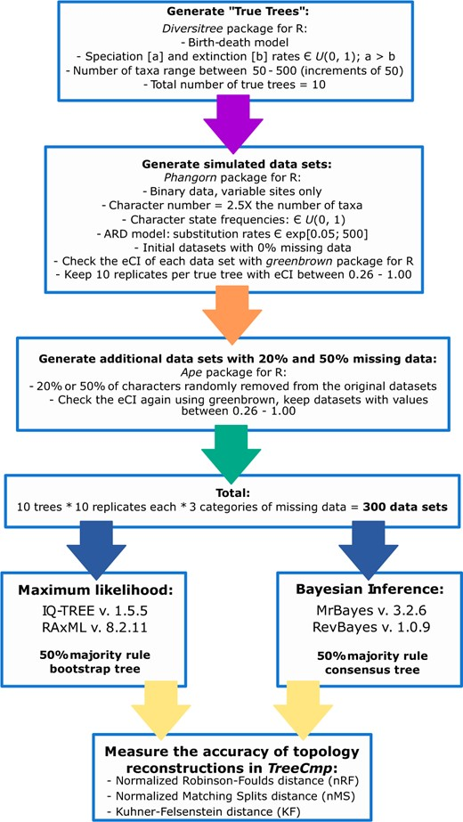

[Open in new tab](https://academic.oup.com/view-large/figure/209351197/syaa020f1.tif)Download slide

Flow chart of study design outlining details of each step of dataset simulations, phylogenetic analyses, and performance assessment.

Table 1.

Summary of simulation parameters and phylogenetic analyses settings.

| Parameter | Simulation | Analysis IQ-TREE | Analysis RAxML | Analysis MrBayes | Analysis RevBayes |
| --- | --- | --- | --- | --- | --- |
| Tree Topologies | Variable: 10 | topologies Uniform + Topology search: NNI | Uniform + Topology search: SPR | Uniform + Topology search: NNI+SPR+TBR | Uniform + Topology search:NNI+SPR |
| Tree model/Branch Lenghts (V) | Birth-Death [b-d U(0,1); b>d] | V optimized tomaximize tree likelihood | V optimized to maximize tree likelihood | Unconstrained: V'-Dirichlet (1.0,0.100,1.0,1.0) Unconstrained: V ' exp( exp(0.2)) |  |
| Character variability model | Variable-only | Variable-only + ASC | Variable-only + ASC | Variable-only + ASC | Variable-only + ASC |
| Character substitution rates () | Variable: exp[0.05;500] | Fixed: 1.0 | Fixed: 1.0 | Fixed: 1.0 | Fixed: 1.0 |
| Rate variation among characters (C) | Variable: ARDmodel | Variable: C 4 discrete categories | Variable: C 4 discrete categories | Variable: C [mean exp(1.0)] 4 discrete categories | Variable: C [mean U(0.0, 1E6)] 4 discrete categories |
| Character state frequencies () | Variable: U(0,1) | Fixed: 0=0.5,1=0.5 | Fixed: 0=0.5,1=0.5 | Fixed: 0=0.5,1=0.5 | Fixed: 0=0.5,1=0.5 |

[output not shown]

Abbreviations: ARD, all rates different model; ASC, ascertainment bias correction; NNI, nearest-neighbour-interchange; SPR, subtree-pruning-and-regrafting; TBR, tree-bisection-andreconnection.

[Open in new tab](https://academic.oup.com/view-large/209351198)

Table 1.

Summary of simulation parameters and phylogenetic analyses settings.

[output not shown]

[output not shown]

Abbreviations: ARD, all rates different model; ASC, ascertainment bias correction; NNI, nearest-neighbour-interchange; SPR, subtree-pruning-and-regrafting; TBR, tree-bisection-andreconnection.

[Open in new tab](https://academic.oup.com/view-large/209351198)

### True Tree Simulations

We generated true tree topologies under the birth-death model using the *diversitree* (FitzJohn 2012) package for R (RC Team 2018). Speciation and extinction rates were sampled randomly from a uniform distribution conditioned on speciation rate being higher than extinction rate. To investigate the effects of taxon number on the performance of each method, we generated ten different true trees with the number of terminal taxa ranging from 50 to 500, using increments of 50.

Using several simulated true tree topologies to assess phylogenetic performance reduces biases that may be introduced by choosing a single tree topology to generate all dataset replicates (Rannala et al. 1998), and allows generation of trees with distinct shapes (such as various degrees of tree asymmetry) and branch lengths. Variation in the number of taxa also allows for an assessment of the impact of increased taxon sampling, which generally leads to more complex phylogenetic problems and is becoming increasingly common in the literature. Generating datasets based on simulated trees rather than empirical ones also has an additional advantage: in the latter case the method used to derive the empirical topology is likely to be favored in terms of performance in the analysis of the simulated datasets (Rannala et al. 1998). Therefore, our simulations differ from previous studies that either assessed the performance of different optimality criteria using datasets simulated from as few as one or two true trees or used empirical trees from the literature (Wright and Hillis 2014, O’Reilly et al. 2016, O’Reilly et al. 2018a, Puttick et al. 2019).

### Dataset Simulations

For each of the ten true trees, we simulated ten binary morphological datasets using the *phangorn* (Schliep 2011) package for R (RC Team 2018). We set the number of characters in each matrix to be 2.5 times the number of taxa (e.g., 125 characters for a 50-taxon topology), based on the average number of characters per taxon in empirical datasets (Scotland et al. 2003). Each character was simulated independently with a unique and randomly generated set of substitution rate and state frequency parameters. We generated variable characters to reflect the compositional bias of empirical morphological datasets, which usually include only traits that vary among taxa, while invariable traits are omitted.

We generated data matrices under the all-rates-different (ARD) model with substitution rates randomly sampled from an exponential distribution ( <sup>a</sup> [0.05; 500]) which allows for asymmetrical substitution rates violating the assumptions of a time-reversible Mk model (Lewis 2001). Character state frequencies were randomly sampled from a uniform distribution for each character. To ensure that our datasets met empirically plausible levels of homoplasy, we only used datasets with ensemble consistency index (eCI) values between 0.26 and 1.0 (Sanderson and Donoghue 1989). The eCI differs from individual character consistency index (cCI) in that it is an overall measure of character homoplasy in a dataset (Goloboff et al. 2018); while different datasets may have similar eCI values, the distribution of individual character homoplasy may vary considerably between them. Thus, generating datasets with very different numbers of taxa and character composition will also introduce an important variation in both eCI and cCI values among datasets. Distributions of homoplasy across characters and the proportion of characters with cCI 1 for our simulated datasets are shown in [Supplementary Figure S1](https://datadryad.org/stash/share/7RZ-T7dDDRcgPO20eSqItLOxRn4e25K17z6smei_rMs) available on Dryad.

We note that our simulation approach differs from that of Puttick et al. (2019), which implemented morphological data simulations with no assumption of shared branch lengths among characters. (Puttick et al. 2019) used this approach in order to provide a performance comparison between probabilistic and parsimony methods but noted that it does not necessarily represent a realistic model of morphological evolution. Since we test only probabilistic methods herein, this model is not relevant to our comparisons and was not used in our study.

Lastly, we generated two additional categories of datasets that contained 20% and 50% missing data by randomly sampling and removing data entries from the original simulated matrices while ensuring that characters remained variable after data removal. This strategy does not necessarily reflect the empirically observed distribution of missing data in empirical datasets (see alternative approaches by Wright and Hillis (2014) and Guillerme and Cooper (2016)), but it is a necessary simplification for testing a large number of simulated datasets with variable numbers of taxa.

### Phylogenetic Analyses

For our phylogenetic analyses, we used settings commonly reported in the empirical analysis of morphological datasets using probabilistic methods and applied those settings to all datasets with minimal variation between them. This approach is a necessary simplification in order to produce representative sampling of results for each software; therefore, empirical analyses with customized or fine-tuned settings may behave differently from the patterns observed in our study. However, the most important parameters to maintain empirical realism were taken into account and adjusted if required. For instance, with every increase in the number of taxa under BI, we increased the number of generations to values commonly used in empirical morphological datasets (between 10-20 million generations) to ensure that all analyses would reach the stationarity phase and attain convergence between runs. We used two independent runs, each with multiple chains, to assess convergence between runs, as is commonly done with empirical datasets using MrBayes and RevBayes, and note that simulated datasets tend to reach stationarity and convergence between runs in fewer generations than empirical datasets. All phylogenetic analyses were conducted on the Cedar and Graham computing clusters available through Compute Canada.

#### Maximum likelihood analyses.

Simulated datasets were analyzed in IQ-TREE v. 1.5.5 (Nguyen et al. 2015) and RAxML v.8.2.11 (Stamatakis 2014). IQ-TREE is a time efficient ML-based software designed specifically to overcome the problem of multiple local optima during the tree search process. The software uses multiple starting trees (100 parsimony trees and a BIONJ tree by default) and iterative stochastic Nearest-Neighbour-Interchange (NNI) rearrangements of candidate trees in a greedy hill-climbing tree search algorithm (Nguyen et al. 2015). By retaining and updating the pool of candidate trees, IQ-TREE should achieve a more thorough exploration of tree space compared to other programs that use a single starting tree.

We used the Mk+R+ASC model in our IQ-TREE analyses, which is a time-reversible model that assumes equal rates of character change and equal state frequencies (Lewis 2001), but allows for free rate heterogeneity across sites, (+R option with four discrete rate categories, Yang 1995, Soubrier et al. 2012). The ASC flag corrects for any artificial increase in branch lengths due to the use of exclusively variable characters, which is known to cause an overestimation of divergence in phylogenetic analyses (Leache et al. 2015). We conducted 1000 ultrafast bootstrap replicates (Minh et al., 2013) and 1000 SH-aLRT branch test replicates (Guindon et al., 2010). All bootstrap replicates were saved (-wbt command option) and used to construct 50% majority rule consensus trees in the *ape* package implemented in R. The use of bootstrapped consensus trees minimizes bias across performance comparisons introduced by the difference in resolution of reconstructed topologies (Brown et al. 2017).

RAxML is another popular software for ML inference of phylogenetic trees with a special focus on large phylogenetic datasets (Stamatakis 2006, 2014). The RAxML search algorithm uses a single randomized stepwise sequence addition parsimony tree (default function) as a starting tree for the subsequent heuristic hill-climbing tree search. The software employs a subtree pruning-and-regrafting (SPR) algorithm to rearrange candidate trees. This approach is more computationally intensive compared to the NNI approach implemented in IQ-TREE; therefore, to accelerate analyses, RAxML uses “lazy subtree rearrangements” with a limited rearrangement distance and omits likelihood calculations for the subtree branches if re-grafting results in a poor likelihood score at the insertion point (Stamatakis et al. 2005, 2007).

We specified the binary model for morphological data with gamma-distributed rate heterogeneity across sites and ascertainment bias correction (-m ASC_BINGAMMA –asc-corr lewis). We conducted a simultaneous ML search and a rapid bootstrap analysis with 1000 replicates in a single RAxML run (-f a). As with the IQ-TREE analyses, we summarized RAxML bootstrap replicates by constructing 50% majority rule consensus trees using the *ape* package for R.

Note that the bootstrap strategies implemented in IQ-TREE and RAxML use distinct algorithms, which may create a considerable disparity in the resulting consensus trees. The ultrafast bootstrapping implemented in IQ-TREE is a widely-used feature of this software which significantly speeds up the bootstrapping procedure (Minh et al. 2013). This gain in computational time efficiency, however, may come at a cost of overestimating branch support under certain conditions (Minh et al. 2013, Hoang et al. 2017). Although there is an option to use a standard bootstrapping approach in IQ-TREE, comparing the ultrafast method in IQ-TREE to the standard approach implemented in RAxML represents an important variable that should be assessed using the RF, MS, and KF metrics so that it can be adequately considered by potential users of either software.

#### Bayesian inference analyses.

Bayesian inference is a statistical approach that estimates posterior distributions of parameter values given the data, probabilistic model of evolution, and prior distributions of parameter values. In phylogenetics, BI uses Markov Chain Monte-Carlo (MCMC) algorithms to sample parameter space including a phylogenetic tree landscape. Unlike the hill-climbing algorithms used in ML software, MCMC sampling allows for “downhill” moves if the likelihood score of a proposed move is above a certain threshold. This non-greedy algorithm, implemented over many iterations, allows for a very thorough exploration of parameter space and avoids the problem of getting stuck on local optima. Furthermore, an even more efficient search is possible with the implementation of the Metropolis Coupled MCMC (MC approach in which the parameter value landscape is explored using additional “heated” chains that help in moving over the “valleys” of low likelihood scores while searching for a global optimum.

BI analyses were conducted using MrBayes v.3.2.6 (Ronquist et al. 2012) and RevBayes v.1..9 (Höhna et al. 2016). In MrBayes, the MC search is initiated from a random tree (unless a starting tree is specified) and proceeds using NNI, SPR (random and parsimony-biased) and tree-bisection-and-reconnection (TBR) by default for non-clock analyses. The rearrangement algorithm and how much time the program dedicates to each procedure can be modified by the user, but the default parameters were used here for better comparison with most published results using morphological data. Rate heterogeneity among characters was sampled from a gamma distribution with four discrete categories, and the number of generations varied between 10 and 20 million generations. Two independent runs were performed for each analysis with either four or eight chains per run.

Like MrBayes, RevBayes starts with a random tree that is subsequently rearranged using NNI, SPR, or both algorithms, as specified by the user in a RevBayes script. The software is very flexible and allows users to specify how much weight the program should assign to each of the rearrangement algorithms if both are used in the analysis. Although RevBayes does not implement a TBR branch swapping algorithm, the iterative nature of the MCMC sampling using guided tree proposals (Höhna and Drummond 2012) and the slice-sampling incorporated in RevBayes (Besag and Green 1993) allow a thorough and efficient exploration of the phylogenetic tree space. In the benchmark assessment of RevBayes against two other BI phylogenetic software packages (BEAST and MrBayes), Höhna et al. (2016) demonstrated that RevBayes performed on par or better than basic implementations of BEAST and MrBayes in terms of computational time. We used the Mkv model for morphological data with four discrete categories of gamma distribution of the acrosssite rate heterogeneity. Each analysis had two independent runs with 1020 million iterations.

For both MrBayes and RevBayes analyses, the convergence of independent runs was assessed across randomly selected outputs using the average standard deviation of split frequencies (ASDSF); all analyses that were assessed had reached convergence (ASDSF 0.01). We note that in order to focus on evaluating topology reconstructions both within and between optimality criteria, we opted to conduct non-clock BI analyses. Due to this, BEAST and BEAST2 (Bouckaert et al. 2014, Suchard et al. 2018) were not included in this study as they implement clock-based analyses only, and estimate time-calibrated trees before branch lengths (total number of substitutions per branch) are calculated (Drummond & Rambaut 2009; Drummond & Bouckaert 2015; Bouckaert et al. 2019). Consequently, BEAST trees are not directly comparable to the non-clock analyses conducted using MrBayes and RevBayes.

In summary, we included 300 datasets in our study. We simulated ten true trees with ten replicates per tree, and then simulated morphological data matrices under three categories of missing data for each true tree. Each simulated dataset was analysed using the four phylogenetic programs described above, totalling 1200 individual analyses. Datasets and scripts used to generate data matrices are available on Dryad at https://doi.org/10.5061/dryad.36cq8k2.

### Performance Assessment

To assess performance across different software, we evaluated: i) accuracy, based on the distance between the true tree and the estimated trees (measured with two different tree distance metrics, see below); ii) precision, based on the total range of tree distance values for each taxon sampling category (i.e., concentration of tree distance results around a single tree distance value); and iii) resolution, based on the proportion of fully resolved nodes in a tree relative to the number of nodes in a fully resolved topology with the same number of terminal taxa.

To calculate accuracy and precision, we used two distinct metrics implemented in TreeCmp (Bogdanowicz and Giaro 2012a): Robinson-Foulds (RF) distance (Robinson and Foulds 1981), and the Matching Splits (MS) metric (Bogdanowicz and Giaro 2012a). The RF metric measures the number of different bifurcations in the compared topologies (in the TreeCmp implementation, it is the total number of different splits in two trees divided by two). The MS metric is a measure of the minimum cost of matching bifurcations between two topologies. For both metrics, higher values (closer to 1) indicate a decrease in accuracy. The use of these two approaches allows assessment of whether different metrics affect the interpretation of phylogenetic accuracy and precision.

Because absolute tree distance increases with an increase in the number of taxa, comparing tree distance results across datasets with different numbers of taxa requires normalizing both the RF and MS metrics (Bogdanowicz et al. 2012b). Therefore, we report here only the normalized RF (nRF) and MS (nMS) metric values calculated in TreeCmp (raw distance values divided by pre-computed average distance values for random trees generated under the uniform model).

We additionally calculated KF (Kuhner and Felsenstein 1994) distance implemented in the *phangorn* package (Schliep 2011) for R. The KF metric calculates the sum of squares of the differences between the length of each branch in the two compared trees. Branches that are not shared between compared topologies are set to length 0. For trees with identical branch lengths, the KF distance is 0. Because there is no maximum possible value for the branch length metric to normalize across different tree topologies with variable numbers of taxa, we measured accuracy of the branch length reconstruction using a rank test; for each individual dataset replicate, phylogenetic inference programs were ranked according to the accuracy of the branch length reconstruction (1 rank = most accurate, 4 rank = least accurate). We then compared total rank scorings for each program across all dataset replicates in each of the three categories of missing data. To compare the performance assessment across different metrics (nRF, nMS, KF), we also performed rank tests for the nRF and nMS metric results. All comparative analyses used unrooted trees, and since resolution has a direct effect on the accuracy of metric estimations (Brown et al. 2017), we also calculated the relative resolution of each reconstructed topology.

## Results

### Effect of the Number of Taxa

Overall, accuracy and precision of tree reconstruction for each software implementation improved as the size of the dataset increased, irrespective of the amount of missing data or the metric used to measure tree distances (Fig. 2). When measured using nRF distance, BI software applications were more accurate than ML programs, regardless of the amount of missing data (Fig. 2; Table 2). MrBayes and RevBayes performed similarly and were the most accurate methods overall (Fig. 2; Table 2). IQ-TREE was substantially less accurate than RAxML in smaller datasets (50-100 taxa), although the accuracy of both ML applications improved considerably as taxon number increased ([Supplementary Table S1](https://datadryad.org/stash/share/7RZ-T7dDDRcgPO20eSqItLOxRn4e25K17z6smei_rMs)).

Figure 2.

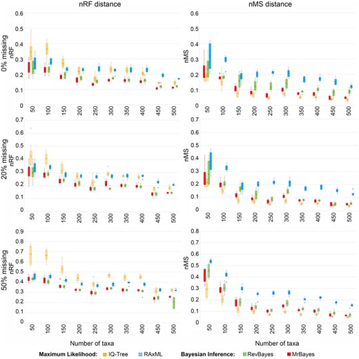

[Open in new tab](https://academic.oup.com/view-large/figure/209351229/syaa020f2.tif)Download slide

Normalized Robinson-Foulds (nRF, left column) and Matching Splits (nMS, right column) values for all methods across three categories of missing data: top—0% missing data; middle—20% missing data; bottom—50% missing data. Mean value for each series of replicates is indicated by ; median values are indicated by horizontal dashes.

Table 2.

Median and standard deviation values of the normalized Robinson-Foulds (nRF)distances for the simulated datasets grouped into five bins.

| Taxa | 0% missing data IQ-Tree Mdn | 0% missing data IQ-Tree St.dev | 0% missing data RAxML Mdn | 0% missing data RAxML st.dev. | 0% missing data MrBayes Mdn | 0% missing data MrBayes st.dev. | 0% missing data RevBayes Mdn | 0% missing data RevBayes st.dev. | 20% missing data IQ-Tree Mdn | 20% missing data IQ-Tree st.dev. | 20% missing data RAxML Mdn | 20% missing data RAxML st.dev. | 20% missing data MrBayes Mdn | 20% missing data MrBayes st.dev. | 20% missing data RevBayes Mdn | 20% missing data RevBayes st.dev. | 50% missing data IQ-Tree Mdn | 50% missing data IQ-Tree st.dev. | 50% missing data RAxML Mdn | 50% missing data RAxML st.dev. | 50% missing data MrBayes Mdn | 50% missing data MrBayes st.dev. | 50% missing data RevBayes Mdn | 50% missing data RevBayes st.dev. |
| --- | --- | --- | --- | --- | --- | --- | --- | --- | --- | --- | --- | --- | --- | --- | --- | --- | --- | --- | --- | --- | --- | --- | --- | --- |
| 50–100 | 0.341 | 0.064 | 0.270 | 0.036 | 0.223 | 0.036 | 0.224 | 0.038 | 0.409 | 0.075 | 0.341 | 0.031 | 0.288 | 0.046 | 0.286 | 0.046 | 0.666 | 0.070 | 0.452 | 0.024 | 0.432 | 0.027 | 0.423 | 0.028 |
| 150–200 | 0.244 | 0.038 | 0.230 | 0.013 | 0.173 | 0.019 | 0.185 | 0.020 | 0.291 | 0.041 | 0.276 | 0.016 | 0.218 | 0.024 | 0.233 | 0.024 | 0.485 | 0.064 | 0.399 | 0.026 | 0.342 | 0.030 | 0.337 | 0.025 |
| 250–300 | 0.206 | 0.038 | 0.231 | 0.017 | 0.145 | 0.016 | 0.165 | 0.015 | 0.271 | 0.046 | 0.271 | 0.013 | 0.195 | 0.026 | 0.180 | 0.016 | 0.443 | 0.051 | 0.371 | 0.019 | 0.321 | 0.027 | 0.326 | 0.028 |
| 350–400 | 0.213 | 0.022 | 0.224 | 0.017 | 0.155 | 0.012 | 0.160 | 0.013 | 0.269 | 0.016 | 0.275 | 0.014 | 0.197 | 0.013 | 0.197 | 0.014 | 0.448 | 0.022 | 0.391 | 0.016 | 0.319 | 0.013 | 0.319 | 0.018 |
| 450–500 | 0.143 | 0.010 | 0.175 | 0.014 | 0.109 | 0.007 | 0.119 | 0.008 | 0.183 | 0.017 | 0.214 | 0.016 | 0.143 | 0.010 | 0.142 | 0.012 | 0.318 | 0.021 | 0.322 | 0.011 | 0.252 | 0.015 | 0.246 | 0.046 |

[Open in new tab](https://academic.oup.com/view-large/209351230)

Table 2.

Median and standard deviation values of the normalized Robinson-Foulds (nRF)distances for the simulated datasets grouped into five bins.

[output not shown]

[Open in new tab](https://academic.oup.com/view-large/209351230)

Table 3.

Median and standard deviation values of the normalized Matching Splits (nMS) distances for the simulated datasets grouped into five bins.

[output not shown]

[Open in new tab](https://academic.oup.com/view-large/209351232)